# COMPSCIX 415.2 Homework 3

Bryan Hee

February 13, 2018

## Section 3.8.1

### Question 1

The problem with the plot is that there is a quite a bit of overlapping data. To better communicate the information, you could use position = “jitter” to remove the overplotting effects.

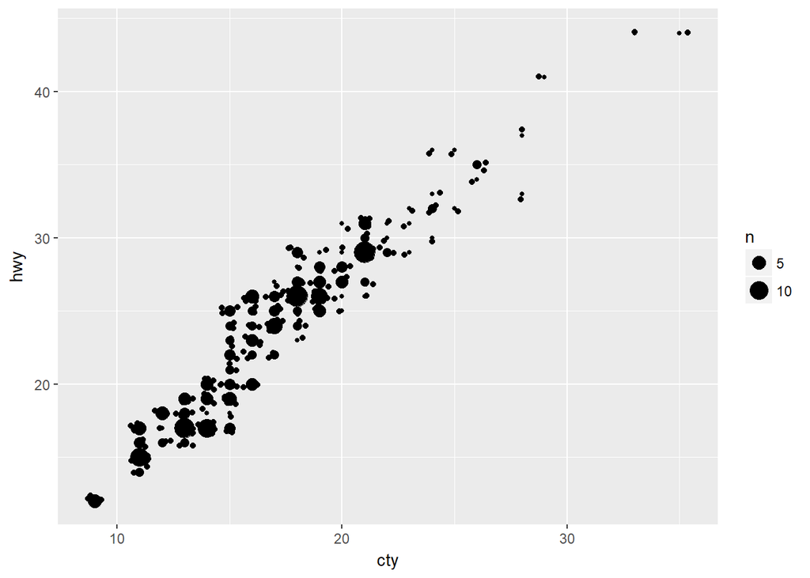

```r
ggplot(data = mpg, mapping = aes(x = cty, y = hwy)) +
  geom_point(position = "jitter") +
  geom_count()
```

### Question 2

The parameters that control the amount of jittering within the geom_jitter() geom are width and height

### Question 3

geom_count counts the number of observations at each location and then displays that information as a count to point area. The geom geom_jitter on the otherhand changes the observations’ values slightly to better see the disagregated sample graphically. geom_count is more useful if you are trying to understand exactly how much overplotting is occuring and where the highest densities of overplotting occur, whereas geom_jitter is more useful in seeing the representational data sample.

### Question 4

The default position for the geom boxplot is dodge.

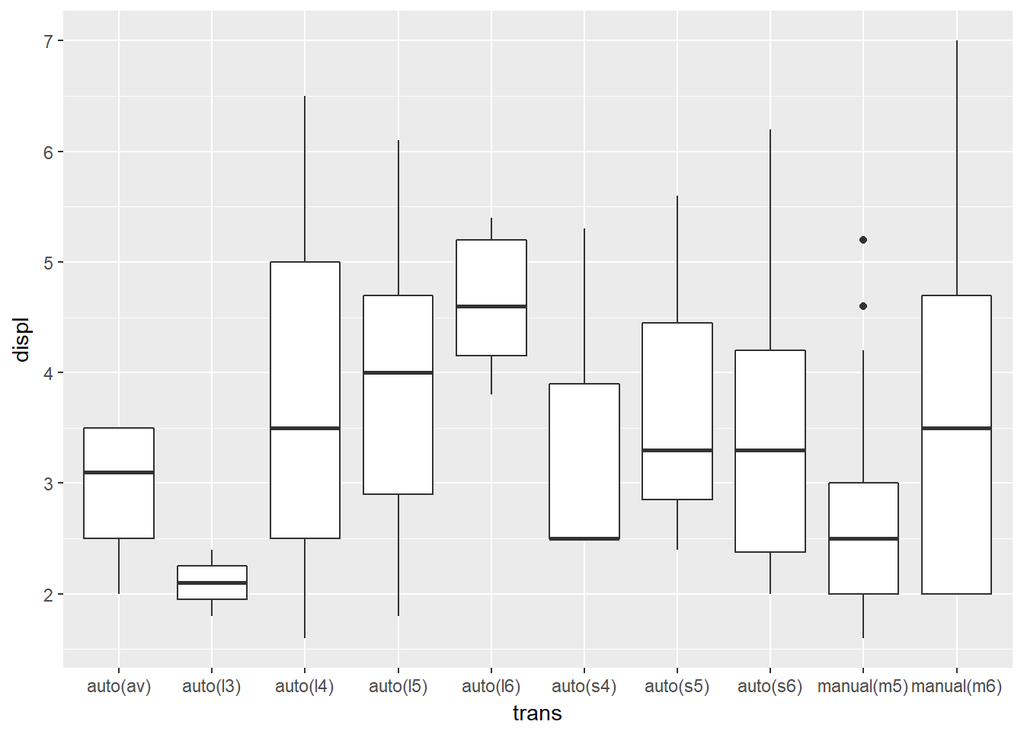

```r
ggplot(data = mpg, mapping = aes(x = trans, y = displ)) +
  geom_boxplot()
```